# ANN Model

Ellen Grehan, Sean Graham, Jason Jiang, Zaid Omari, Samantha Pelter

2026-10-22

```r
library(ggplot2)
library(caret)
library(neuralnet)
library(gmodels)
```

# The ANN Model

Our business question is whether team statistics and seeds can predict the winner of a March Madness game better than just picking the better (lower) seed. This file builds the **artificial neural network (ANN)** for that question.

# Modeling and Prediction (ANN)

Now, we will create the ANN model. The network passes each game’s statistics through hidden “neurons,” which each learn a weighted combination of the inputs, and turns the result into a probability that team 1 wins.

### Loading the Training and Test Data

```r
# Load the train and test sets saved by Data_Cleaning.Rmd
madness_train <- readRDS("training_data.rds")
madness_test  <- readRDS("testing_data.rds")

dim(madness_train)
```

```
## [1] 682  92
```

```r
dim(madness_test)
```

```
## [1] 682  92
```

```r
# winner = 1 if team 1 won the game, 0 if team 2 won
table(madness_train$winner)
```

```
##
##   0   1
## 246 436
```

```r
table(madness_test$winner)
```

```
##
##   0   1
## 233 449
```

### Normalizing the Data

Neural networks train much better when every input is on the same 0-1 scale. Otherwise, a column like points per game (around 70) would completely overpower a column like win percentage (around 0.7). We use min-max normalization, like the class demo.

```r
# Min-max normalization function from class
normalize <- function(x) {
  (x - min(x)) / (max(x) - min(x))
}

# Every column is already numeric
str(madness_train[, 1:10])
```

```
## 'data.frame':    682 obs. of  10 variables:
##  $ seed.1        : int  2 3 7 7 5 4 7 2 6 2 ...
##  $ seed.2        : int  15 14 15 10 12 13 10 15 11 15 ...
##  $ round         : int  1 1 2 1 1 1 1 1 1 1 ...
##  $ winner        : num  1 1 0 0 1 1 1 1 0 1 ...
##  $ win_pct.1     : num  0.886 0.694 0.676 0.714 0.75 0.75 0.857 0.919 0.656 0.788 ...
##  $ srs.1         : num  20.9 23.8 12.9 13.8 15.8 ...
##  $ sos.1         : num  7.23 11 6.14 7.24 7.44 ...
##  $ win_pct_home.1: num  1 0.786 0.933 0.895 1 ...
##  $ win_pct_away.1: num  0.778 0.6 0.4 0.444 0.4 ...
##  $ win_pct_conf.1: num  0.875 0.625 0.562 0.611 0.7 ...
```

```r
# Stack train and test, normalize them together so both use the same scale, then split them back apart
madness_all <- rbind(madness_train, madness_test)
norm_all <- as.data.frame(lapply(madness_all, normalize))

norm_train <- norm_all[1:nrow(madness_train), ]
norm_test  <- norm_all[(nrow(madness_train) + 1):nrow(norm_all), ]

summary(norm_train[, 1:6])
```

```
##      seed.1            seed.2           round            winner
##  Min.   :0.00000   Min.   :0.0000   Min.   :0.0000   Min.   :0.0000
##  1st Qu.:0.06667   1st Qu.:0.2000   1st Qu.:0.0000   1st Qu.:0.0000
##  Median :0.26667   Median :0.6000   Median :0.0000   Median :1.0000
##  Mean   :0.25396   Mean   :0.5257   Mean   :0.1672   Mean   :0.6393
##  3rd Qu.:0.40000   3rd Qu.:0.8000   3rd Qu.:0.2000   3rd Qu.:1.0000
##  Max.   :1.00000   Max.   :1.0000   Max.   :1.0000   Max.   :1.0000
##    win_pct.1           srs.1
##  Min.   :0.09389   Min.   :0.0000
##  1st Qu.:0.39847   1st Qu.:0.5644
##  Median :0.55677   Median :0.6403
##  Mean   :0.55180   Mean   :0.6473
##  3rd Qu.:0.71179   3rd Qu.:0.7244
##  Max.   :0.99563   Max.   :1.0000
```

### Baselines to Beat

Before building the network, we need to know what “good” looks like on these test games.

```r
# Baseline 1: always pick team 1
mean(madness_test$winner == 1)
```

```
## [1] 0.6583578
```

```r
# Baseline 2: pick the better (lower) seed; for equal seeds, pick team 1
seed_pick <- ifelse(madness_test$seed.1 <= madness_test$seed.2, 1, 0)
mean(seed_pick == madness_test$winner)
```

```
## [1] 0.7140762
```

Always picking team 1 is right 65.8% of the time, and picking the better seed is right 71.4% of the time. Picking by seed is how most people fill out a bracket, so 71.4% is the real bar the ANN has to clear.

### Creating the Model

We start with the same shape as the class demo: one hidden neuron.

```r
set.seed(12345)

# 1 hidden neuron
ann_model <- neuralnet(winner ~ ., data = norm_train, hidden = 1,
                       linear.output = FALSE, stepmax = 1e6, lifesign = "minimal")
```

```
## hidden: 1    thresh: 0.01    rep: 1/1    steps:   35077  error: 30.50463 time: 6.56 secs
```

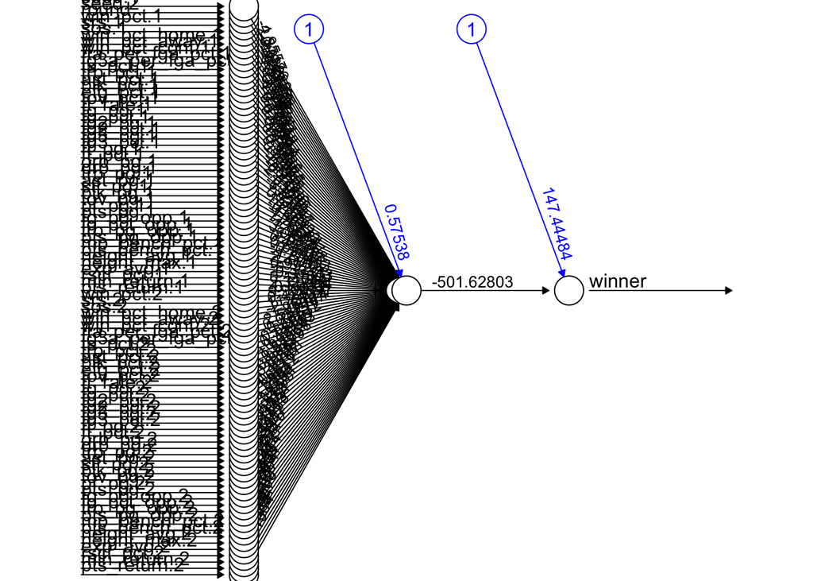

```r
# Plot the network with all of its weights
plot(ann_model, rep = "best")
```

```r
# Test-set accuracy and Kappa of the 1-neuron network
ann_pred <- ifelse(predict(ann_model, norm_test) > 0.5, 1, 0)
confusionMatrix(as.factor(ann_pred), as.factor(norm_test$winner), positive = "1")$overall[c("Accuracy", "Kappa")]
```

```
##  Accuracy     Kappa
## 0.7360704 0.4263176
```

The 1-neuron network is right on 73.6% of the test games, with a Kappa of 0.426. It already beats both baselines.

### Improving the Model

Next, we test whether more neurons or a second hidden layer help. For each shape we record the test accuracy, Kappa, sensitivity (team 1 wins called correctly) and specificity (team 2 wins called correctly). Because team 1 wins most games, Kappa is our main measure.

```r
shapes <- list(1, 2, 3, 5, c(2, 1), c(3, 1), c(3, 2))

ann_results <- data.frame()
for (h in shapes) {
  set.seed(12345)
  ann_h <- neuralnet(winner ~ ., data = norm_train, hidden = h,
                     linear.output = FALSE, stepmax = 1e6)
  pred_h <- ifelse(predict(ann_h, norm_test) > 0.5, 1, 0)
  cm_h <- confusionMatrix(as.factor(pred_h), as.factor(norm_test$winner), positive = "1")

  # Save this shape's results as one row
  ann_results <- rbind(ann_results, data.frame(
    hidden      = paste(h, collapse = ", "),
    Accuracy    = round(cm_h$overall["Accuracy"], 3),
    Kappa       = round(cm_h$overall["Kappa"], 3),
    Sensitivity = round(cm_h$byClass["Sensitivity"], 3),
    Specificity = round(cm_h$byClass["Specificity"], 3),
    row.names = NULL))
}

# Sorted from best to worst Kappa
ann_results[order(-ann_results$Kappa), ]
```

```
##   hidden Accuracy Kappa Sensitivity Specificity
## 1      1    0.736 0.426       0.775       0.661
## 6   3, 1    0.713 0.389       0.733       0.674
## 5   2, 1    0.710 0.375       0.744       0.644
## 3      3    0.716 0.365       0.788       0.575
## 2      2    0.714 0.357       0.795       0.558
## 7   3, 2    0.695 0.341       0.737       0.614
## 4      5    0.702 0.338       0.775       0.562
```

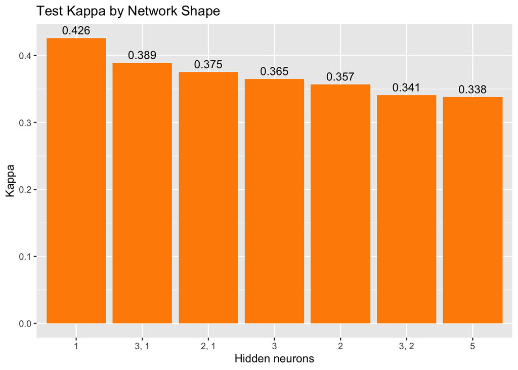

```r
# Test Kappa for each network shape
ggplot(ann_results, aes(x = reorder(hidden, -Kappa), y = Kappa)) +
  geom_col(fill = "darkorange") +
  geom_text(aes(label = Kappa), vjust = -0.5) +
  labs(title = "Test Kappa by Network Shape", x = "Hidden neurons", y = "Kappa")
```

**The 1-neuron network is the best**, with the highest accuracy (73.6%) and Kappa (0.426) of the 7 shapes. Adding neurons made the network worse: 5 neurons drops Kappa to 0.338. With 91 inputs, every extra neuron adds 92 more weights to learn from only 682 training games, so bigger networks start memorizing the training games instead of learning real patterns. We keep the 1-neuron network as our final model.

```r
# Predicted probability that team 1 wins each test game
ann_prob <- as.vector(predict(ann_model, norm_test))
summary(ann_prob)
```

```
##    Min. 1st Qu.  Median    Mean 3rd Qu.    Max.
##  0.0000  0.0000  1.0000  0.6259  1.0000  1.0000
```

Almost every probability is very close to 0 or 1, so the network is very sure of its picks. Because of this, moving the cutoff from 0.5 to 0.3 (which helps many models) would change almost no predictions.

# Confusion Matrix and Interpretation

```r
# Predict a team 1 win (1) when the probability is above 0.5
ann_bin <- ifelse(ann_prob > 0.5, 1, 0)

# Rows = actual winner, columns = predicted winner (1 = team 1)
CrossTable(x = norm_test$winner, y = ann_bin, prop.chisq = FALSE)
```

```
##
##
##    Cell Contents
## |-------------------------|
## |                       N |
## |           N / Row Total |
## |           N / Col Total |
## |         N / Table Total |
## |-------------------------|
##
##
## Total Observations in Table:  682
##
##
##                  | ann_bin
## norm_test$winner |         0 |         1 | Row Total |
## -----------------|-----------|-----------|-----------|
##                0 |       154 |        79 |       233 |
##                  |     0.661 |     0.339 |     0.342 |
##                  |     0.604 |     0.185 |           |
##                  |     0.226 |     0.116 |           |
## -----------------|-----------|-----------|-----------|
##                1 |       101 |       348 |       449 |
##                  |     0.225 |     0.775 |     0.658 |
##                  |     0.396 |     0.815 |           |
##                  |     0.148 |     0.510 |           |
## -----------------|-----------|-----------|-----------|
##     Column Total |       255 |       427 |       682 |
##                  |     0.374 |     0.626 |           |
## -----------------|-----------|-----------|-----------|
##
##
```

```r
# Save the confusion matrix so it can be exported at the end
ann_confusion <- confusionMatrix(as.factor(ann_bin), as.factor(norm_test$winner), positive = "1")
ann_confusion
```

```
## Confusion Matrix and Statistics
##
##           Reference
## Prediction   0   1
##          0 154 101
##          1  79 348
##
##                Accuracy : 0.7361
##                  95% CI : (0.7013, 0.7688)
##     No Information Rate : 0.6584
##     P-Value [Acc > NIR] : 7.633e-06
##
##                   Kappa : 0.4263
##
##  Mcnemar's Test P-Value : 0.1175
##
##             Sensitivity : 0.7751
##             Specificity : 0.6609
##          Pos Pred Value : 0.8150
##          Neg Pred Value : 0.6039
##              Prevalence : 0.6584
##          Detection Rate : 0.5103
##    Detection Prevalence : 0.6261
##       Balanced Accuracy : 0.7180
##
##        'Positive' Class : 1
##
```

In this confusion matrix, a **positive** is a team 1 win. Team 1 is the better seed in about three quarters of games, so a team 2 win is usually an underdog win.

Based on the cross table above, the ANN has an overall accuracy of **73.6%**, since it predicted 502 of the 682 test games correctly (348 team 1 wins plus 154 team 2 wins). That beats always picking team 1 (65.8%) and picking the better seed (71.4%). **Kappa is 0.426.**

**Underdog wins are where the ANN adds value.** Of the 192 test games won by the worse seed, the ANN called 104 correctly, while picking by seed would have missed all 192.

### Saving Predictions and Confusion Matrix for the Stacked Model

```r
# Probability that team 1 wins, one value per test game, in the same order as testing_data.rds
saveRDS(ann_prob, "ANN_stacked_probability.rds")

# The ANN's confusion matrix, so the group can compare every model side by side
saveRDS(ann_confusion, "ANN_confusion.rds")
```